# Financiarisation et « soft power » : les investissements étrangers dans le sport professionnel

Loïc Robinson

POL-6078 – Automne 2025

## 1 - Introduction

Progressivement, le marché du sport professionnel connaît une transformation de ses structures de financement et de propriété, ainsi que de sa gouvernance. Que ce soit à des fins de sportswashing, de renforcement de stratégies géopolitiques plus larges ou de simples rendements monétaires, rares sont les grands clubs ou les grandes franchises qui ne sont pas aujourd’hui détenus par un fonds souverain, une firme de capital-investissement ou de grands gestionnaires d’actifs internationaux. L’investissement massif de ces acteurs est particulièrement visible à l’échelle de ligues majeures nord-américaines comme la National Basketball Association (NBA), la Major League Baseball (MLB) ou la Major League Soccer (MLS), ainsi que des clubs de soccer européens dominants. À ce titre, il importe d’analyser comment l’augmentation des investissements étrangers dans les clubs sportifs nord-américains ou européens contribue à redéfinir le sport professionnel, que ce soit à la fois comme **classe d’actifs financiers** ou comme **instrument de *soft power* économique et politique**.

## 2 - Revue de littérature

Pour réaliser ma revue de littérature, j’ai mobilisé l’outil de synthèse de la connaissance du nom d’*Elicit*, qui propose, usant de l’intelligence artificielle, un survol de la littérature sur un sujet donné puis un onglet qui permet d’interagir avec les résultats. J’ai ensuite eu recours à *Gemini 3 Pro* pour traduire la revue de littérature générée par *Elicit*, ce qui a mené au résultat suivant:

« La littérature examinant l’investissement sportif étranger en tant que mécanisme de projection de soft power est devenue un domaine de recherche significatif. Une analyse systématique révèle que, bien que des montants d’investissement plus élevés soient associés à des gains accrus de soft power, cette relation est fondamentalement conditionnelle plutôt que linéaire (Schepps 2023; Bianco & Sons 2023). Des preuves empiriques démontrent des variations marquées dans les résultats selon les contextes d’investissement. Par exemple, l’acquisition par le Qatar du Paris Saint-Germain pour 1,7 milliard de dollars a généré un levier diplomatique mondial documenté, amélioré les relations internationales, et produit des résultats politiques à long terme, notamment une influence sur l’OPEP et un rôle dans le courtage d’accords internationaux (Katyal 2021). En revanche, le parrainage du FC Schalke par Gazprom, malgré son statut de plus grand parrainage de l’histoire du football allemand (Schepps 2023), n’a produit que des effets régionaux et à court terme, finalement sapés par la politique étrangère antagoniste de la Russie (Schepps 2023).

Les travaux recensés soulignent trois dimensions empiriques récurrentes permettant d’évaluer les effets de ces investissements sur le soft power (Kilcline 2019; Bianco & Sons 2023) : (1) la capacité globale de soft power de l’État investisseur — largement discutée dans la littérature sur la diplomatie sportive comme ressource préalable modulant l’efficacité d’un investissement (Ishac 2018; Chadwick & al. 2020) ; (2) le degré de médiatisation internationale générée par l’acquisition ou le financement d’un club, la visibilité médiatique étant fréquemment décrite comme un mécanisme central de diffusion d’image nationale (Chanavat 2017) ; (3) le statut, la richesse et l’influence institutionnelle de la franchise sportive acquise, plusieurs auteurs notant que les clubs ayant une forte empreinte culturelle ou commerciale offrent un levier symbolique disproportionné dans les stratégies de soft power (Chadwick & Arthur 2017).

Les chercheurs avancent également la théorie selon laquelle le parrainage d’un plus grand nombre d’équipes ayant des marques plus fortes via des sociétés d’État produirait de meilleurs rendements en matière de soft power (Krzyzaniak 2016).

Le cadre théorique englobe de multiples mécanismes causaux : l’association de marque (Krzyzaniak 2016), le contrôle des médias et de la diffusion (Kilcline 2019), l’intégration avec des objectifs stratégiques (Katyal 2021), et les activités de diplomatie sportive (Bianco & Sons 2023). Cependant, la prédominance des méthodologies d’étude de cas qualitatives limite l’inférence causale (Schepps 2023).

Des limites méthodologiques persistent dans le domaine : la plupart des sources manquent de méthodes de mesure explicites pour les résultats de soft power, et aucune étude ne fournit d’analyse contrefactuelle robuste (Schepps 2023). Seulement une étude utilise des données de vote pour mesurer des résultats comportementaux, et une autre emploie des indicateurs financiers (Schepps 2023).

Ainsi, même si le corpus souligne le rôle de la capacité étatique, de la visibilité médiatique et du prestige des clubs dans les stratégies de diplomatie sportive, la force causale de cette relation ne peut être établie de manière définitive à partir des preuves disponibles (Schepps 2023). Ceci souligne des lacunes critiques dans les approches de mesure quantitative et d’analyse longitudinale qui contraignent l’avancement théorique dans la compréhension des mécanismes de la diplomatie sportive (Connell 2017; Schepps 2023). »

## 3 - Question de recherche et hypothèse

L’aperçu du marché du sport professionnel dressé dans la section ci-haut confirme la présence d’une duplicité dans les motifs derrière un investissement international au sein d’une marque sportive (malgré la relative infimité d’études quantitatives à cet effet). Par conséquent, si les rendements économiques peuvent constituer, à l’oeil non averti, le principal moteur des décisions d’investissement dans le sport professionnel, la dimension politique de ces investissements est non-négligeable. Ce projet propose donc de la placer au centre de l’analyse afin d’en examiner l’ampleur vraisemblablement croissante et ses effets. La question de recherche qui guide le projet est la suivante:

**« Dans quelle mesure le montant des investissements étrangers dans les franchises et les clubs sportifs est-il associé à un niveau plus élevé de *soft power* économique et politique de l’État ou de l’acteur investisseur? »**

Mon hypothèse est que l’augmentation du montant des investissements étrangers dans les clubs et franchises sportives nord-américaines est positivement associée à un niveau plus élevé de *soft power* économique et politique de l’État ou de l’acteur investisseur. Dans un second plan, à titre exploratoire, j’émets également l’hypothèse que les investissements provenant de fonds souverains sont associés à des niveaux de *soft power* plus élevés que ceux issus d’acteurs privés traditionnels.

## 4 - Collecte de données

Aucun ensemble de données standardisé ne permet actuellement l’établissement d’un lien entre investissements étrangers dans le sport professionnel et l’acquisition de *soft power* pour les investisseurs. Cette lacune de données quantitatives est notamment relevée dans ma revue de littérature. À cet effet, j’ai eu recours à l’intelligence artificelle de *ChatGPT* pour construire un ensemble de données réaliste s’attardant à 8 franchises ou clubs sportifs: Manchester City FC, Newcastle United, Inter Miami, les Dodgers de Los Angeles, les Raptors de Toronto, l’AC Milan, le Paris Saint Germain et le Arsenal FC. Cela m’a permis de reproduire de manière réaliste la logique d’une telle recherche et, éventuellement, d’explorer la relation théorique énoncée dans ma question de recherche. Les variables retenues reflètent ces dimensions: d’une part, le **montant de l’investissement**, en millions de dollars américains, puis, d’autre part, **l’origine géopolitique** etle **type d’investisseur** qu’il constitue. Ces dernières variables permettent de faire la distinction entre fonds souverains, capitaux privés ou gestionnaires d’actifs.

J’ai ensuite construit un indice fictif de « *soft power* » pour opérationnaliser la variable politique de la chose. Utilisant un score de 1 à 10, cet indice combine les trois dimensions empiriques récurrentes relevées par la revue de littérature, à savoir la **capacité globale de *soft power* de l’État de l’investisseur** (que j’ai calculée à partir du *Global Soft Power Index 2025* de Brand Finance), le **degré de médiatisation de l’investissement** (mesuré par le volume d’articles à travers l’outil de collecte de données médiatiques *Factiva*) ainsi que **l’influence et la fortune de la franchise ou du club détenu** (mesuré en utilisant les résultats de la *Deloitte Football Money League 2025* et du *Forbes Top 50* des franchises et clubs les plus riches au monde). Un score élevé indique conséquemment une probabilité plus forte que l’investissement serve de vecteur géopolitique plutôt que de simple actif financier. Donc, si mon hypothèse est correcte, il devrait exister une relation de renforcement mutuel entre la croissance des montants investis et de l’indice.

À titre de sommaire, ma collecte de données a d’abord utilisé l’intelligence artificielle générative pour construire un ensemble de données réaliste ciblant le type d’investisseurs, leur origine ainsi que le montant investi au sein de grands clubs et franchises prédéterminés. Ensuite, une approche de plus longue haleine m’a vu collecter des données pour opérationnaliser la variable politique du *soft power* par l’entremise de deux outils. Initialement, des **données trouvées sur le Web** m’ont permis de manuellement construire des scores en matière de fortune des clubs et franchises puis de la capacité de *soft power* de leur investisseur ou de l’État duquel celui-ci provient. Subséquemment, j’ai mobilisé *Factiva*, un outil de collecte de données médiatiques, pour attribuer une valeur au degré de médiatisation de chacun des huit investissements. *Factiva*, opéré par Dow Jones, rassemble plus de 15 000 articles ou documents médiatiques pour relever les plus pertinents relatifs à un ensemble de mots-clés. J’ai donc saisi un ensemble de mots-clé donné (par exemple, « Qatar Paris Saint Germain *soft power* ») et attribué des scores en fonction du volume d’articles ressorti par l’outil depuis la date de l’investissement initial. L’agrégat des trois valeurs numériques a été la valeur finale retenue mesurant le degré de *soft power* acquis par l’entremise de l’investissement.

La fiabilité de mon indice de *soft power* construit a été calculé via l’alpha de Cronbach. Cette mesure statistique mesure si les trois dimensions de l’indice captent bien une dimension commune ou si ce dernier représente une construction arbitraire, hasardeuse et manquant de fiabilité. Pour accomplir ceci, j’ai demandé à *ChatGPT* de générer un script *R* en utilisant le package *psych*, que j’ai ensuite roulé dans *RStudio* pour obtenir la valeur de l’alpha. Le résultat (0,97) indique une excellente fiabilité, renforçant la validité interne de mon approche malgré le caractère fictif de l’ensemble de données dont j’ai usé. Il importe toutefois d’interpréter cet alpha avec prudence, puisqu’il peut aussi être synonyme de la mise en ensemble de variables trop similaires plutôt qu’un construit pertinent et complet.

Cette approche inhabituelle à la collecte de données aurait pu être renforcée de plusieurs façons. D’abord, si les données réelles nécessaires à la réalisation d’un l’ensemble de données non-fictif avaient été disponibles librement, ou si un budget m’avait permis un tel accès, j’aurais mobilisé *rvest* pour les extraire en accordance avec les conditions d’utilisation du site Web concerné pour construire un ensemble réel.

## 5 - Analyse et visualisation des données

Mon analyse et ma visualisation de données ont été réalisées en langage *R* dans l’environnement de programmation *RStudio*, une approche qui rend possible la production de visualisations avancées par l’entremise des packages spécialisés. Plus précisément, j’ai utilisé la librairie *tidyverse* pour structurer et manipuler les données de ma collecte, puis *ggplot2* pour générer un graphique de type bubble plot. Ce type de visualisation permet de représenter la logique duale de financiarisation et *soft power* dont la recherche faisait initialement question, alors que la taille des bulles du graphique représente le montant investi, et leur placement, leur provenance et degré de *soft power* perçu.

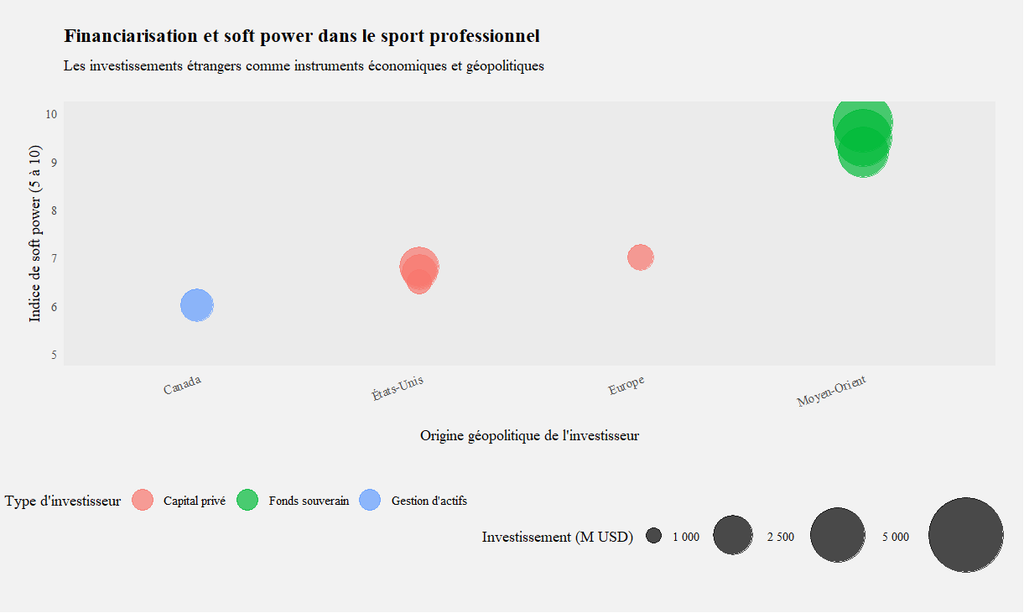

Concernant les hypothèses émises plus haut au sein de ce papier, la visualisation produite confirme une association positive entre le montant des investissements étrangers et le niveau de *soft power* attribué aux investisseurs, alors que les États et fonds souverains occupent les bulles les plus imposantes et les positions les plus élevées sur l’indice. Elle indique également un degré de conditionnalité du « succès » d’un tel investissement étranger selon le contexte géographique de l’investissement, un constat qui avait été établi par la revue de littérature d’Elicit. Ainsi les tendances constatées soutiennent l’idée selon laquelle les investissements sportifs étrangers fonctionnent comme actif financier mais aussi d’outil d’influence politique.

Néanmoins, il en demeure que ces résultats doivent être interprétés avec circonspection en raison du caractère fictif de l’ensemble de données: la validité empirique de l’analyse y perd de la vigueur. Il en va de même en tenant compte de l’indice de *soft power*, construit à l’interne, qui réduit l’objectivité de la recherche. Le faible échantillonage (8 clubs/franchises) réduit quant à lui la généralisation potentielle des tendances observées, et finalement, l’utilisation seule de *Factiva* introduit un biais de sélection médiatique, puisque les dynamiques éditoriales dégagées des sources sont uniquement celles des articles et documents qu’elle indexe (contrairement à si j’avais scrapé le web plus extensivement). Malgré ces limites, les résultats qui sont produits par la recherche démontrent sa logique théorique, ce qui offre une base plausible pour des futurs travaux en la matière.

## 6 - Discussion

Une multitude d’outils numériques sont intervenus tout au long de la réalisation de cette recherche. La sélection de ces outils représente le fruit d’un arbitrage relativement constant qui visait à maximiser la prévalence des valeurs scientifiques de transparence, d’accessibilité et de réplicabilité (principes tirés du cours), puis, dans un second plan, à répondre à mes besoins pratiques, c’est-à-dire de trouver rapidement l’information, construire et analyser une base de données qui, fonctionnellement, n’existait pas, visualiser les résultats et, finalement, publier un travail reproductible. L’utilisation initiale d’**Elicit** pour générer la revue de littérature s’inscrit dans ce prisme. Bien que sa revue narrative demeure limitée dans la version gratuite de l’outil, réduisant son accessibilité dans le sens entendu du cours, son accessibilité méthodologique, à savoir, le survol rapide et structuré qu’il effectue à travers une interface facile à opérer, tout en identifiant ses sources, rendait l’utilisation de cet outil idéale. Ensuite, l’emploi de l’intelligence artificielle générative a répondu à une gamme de besoins beaucoup plus large. **ChatGPT** a notamment permis la construction d’un ensemble de données fictives essentielles à l’opérationnalisation du projet, tout en servant d’expert virtuel pour traiter les erreurs de code qui pouvaient survenir dans **RStudio**. Ces outils manquent cependant de transparence et la vigilance demeure de mise lors de leur utilisation. J’ai choisi de réaliser la construction de mon ensemble de données et l’analyse de ces statistiques dans **R et RStudio** puisqu’il s’agit de deux outils largement utilisés dans le milieu académique et qui représentent parfaitement la philosophie du logiciel libre. Une réplicabilité complète (dans le sens que tout script exécuté peut être reproduit par n’importe quel utilisateur disposant des mêmes packages) caractérise ces outils, ce qui va de pair avec les valeurs fondamentales de ce projet. De plus, la **tidyverse**, **ggplot2** et le package **psych** illustrent aussi la logique populaire, accessible et réplicable du papier, étant tous soutenus par une communauté active. Ainsi, l’environnement **R**, tout au long du projet,a été l’incarnation la plus authentique de la philosophie du logiciel libre en action dans les méthodes scientifiques en sciences sociales. Cette section mérite également que l’on s’attarde à mon utilisation de **Factiva**, outil auquel j’ai pu accéder via la licence institutionnelle de l’Université Laval. Efficae en matière de profondeur documentaire, Factiva demeure toutefois un outil propriétaire et payant, limitant son accessibilité et sa réplicabilité. Finalement, la rédaction en **Markdown (.Rmd)** et la publication du projet via **GitHub** étaient une étape culminante cohérente avec mes valeurs de transparence et d’ouverture. La structure du dossier de mon projet au sein d’un repo de la plateforme respecte notamment la pratique de réplicabilité des données et de la recherche.

## 7 - Bibliographie

Chadwick, Simon, et David Arthur. 2010. « International Cases in the Business of Sport. »

Chadwick, Simon, Paul Widdop, et Nicholas Burton. 2020. « Soft Power Sports Sponsorship – A Social Network Analysis of a New Sponsorship Form. » *Journal of Political Marketing* 21 (2): 196–217.

Chanavat, Nicolas. 2017. « French Football, Foreign Investors: Global Sports as Country Branding. » *The Journal of Business Strategy* 38 (6): 3–10. https://doi.org/10.1108/JBS-04-2017-0053.

Connell, John. 2018. « Globalisation, soft power, and the rise of football in China. » *Geographical Research* 56 (1): 5–15.

Ishac, Wadih. 2018. « Furthering national development through sport, the case of Qatar. »

Katyal, Anay. 2021. « Top Bins: An Exploration of Qatar’s Use of Sport and Capital to Strengthen Diplomatic Visibility. » *Athens Journal of Sports* 8 (4): 271–278. https://doi.org/10.30958/ajspo.8-4-4.

Kilcline, Cathal. 2019. « Plutocrats, Paranoia, Platoche. » Dans *Sport and Society in Global France: Nations, Migrations, Corporations, Studies in Modern and Contemporary France*. Liverpool: Liverpool University Press. https://doi.org/10.3828/liverpool/9781781382899.001.0001.

Krzyzaniak, J. 2018. « The soft power strategy of soccer sponsorships. » *Soccer & Society* 19 (4): 498–515.

Schepps, Caden. 2023. « Geopolitics on a Jersey: Gazprom’s Sponsorship of FC Schalke 04 and its Soft Power Implications. » *Cornell International Affairs Review* 16 (2).

Sons, Sebastian, et Cinzia Bianco. 2023. « More than a Game: Football and Soft Power in the Gulf. » *The International Spectator* 58 (2): 92–106.

Brand Finance. 2025. « Brand Finance Global Soft Power Index 2025: China overtakes UK for the first time, US remains top-ranked nation brand. »

Deloitte. 2025. « Deloitte Football Money League 2025. » https://www.deloitte.com/uk/en/services/consulting-financial/analysis/deloitte-football-money-league.html.

Forbes. 2024. « The World’s 50 Most Valuable Sports Teams 2024. »